# p8105_hw5_kp3127

2025-11-05

# Problem 1

Write a function to check whether there are duplicate birthdays in the group

```r
bd_check <- function(n, days = 365) {
  bdays <- sample.int(days, size = n, replace = TRUE)
  any(duplicated(bdays))
}
```

Compute the probability for each group size between 2 and 50, running 10000 times:

```r
sim_df=
  tibble(gp_size=2:50) %>%
  mutate(prob=map_dbl(.x=gp_size,~mean(replicate(10000,bd_check(.x)))))
```

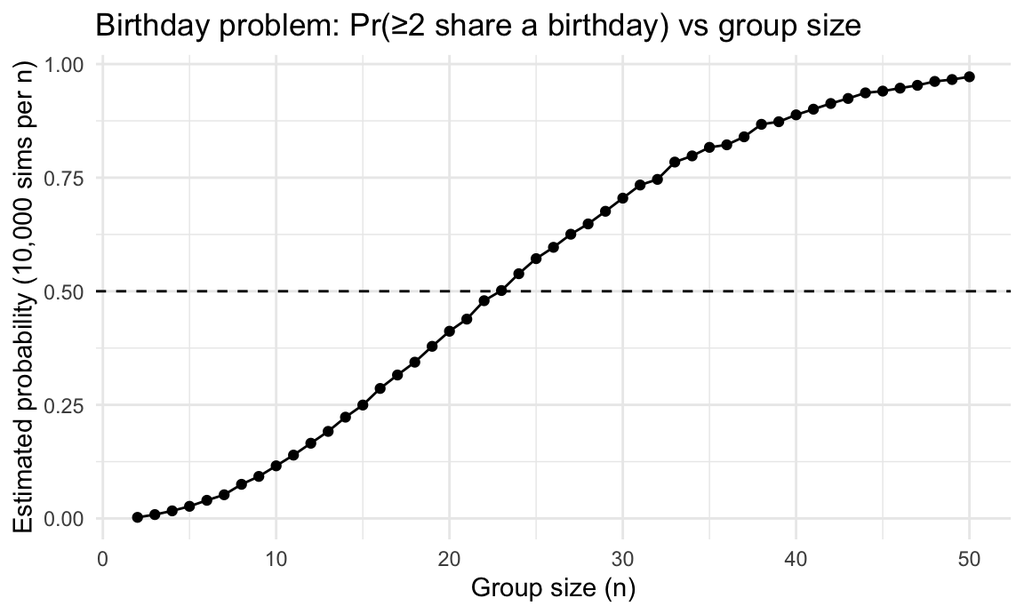

```r
sim_df |>
  ggplot(aes(x = gp_size, y = prob)) +
  geom_line() +
  geom_point() +
  geom_hline(yintercept = 0.5, linetype = 2) +
  labs(
    title = "Birthday problem: Pr(≥2 share a birthday) vs group size",
    x = "Group size (n)",
    y = "Estimated probability (10,000 sims per n)"
  ) +
  theme_minimal()
```

The curve rises monotonically with group size. It crosses 0.50 when n = 23.  
This result matches the classic birthday paradox: with just 23 people, there’s over a 50% chance at least two share a birthday.

# Problem 2

```r
library(broom)
```

For a given mu, create a function to get the results of mu_hat and p-value

```r
set.seed(1)
n      <- 30
sigma  <- 5
mus    <- 0:6
n_sim  <- 5000
alpha  <- 0.05

sim_ttest = function(mu) {
  map_dfr(1:n_sim, function(i) {
    x = rnorm(n, mean = mu, sd = sigma)
    ttest = tidy(t.test(x, mu = 0))
    tibble(
      mu = mu,
      mu_hat = ttest$estimate,
      p = ttest$p.value,
      reject = p < alpha
    )
  })
}
```

Repeat the function for different mu[0:6]

```r
sim_res=map_dfr(mus, sim_ttest)
```

Calculate the power

```r
power_df=sim_res %>%
  group_by(mu) %>%
  summarize(power=mean(reject))
```

Describe the association between effect size and power.

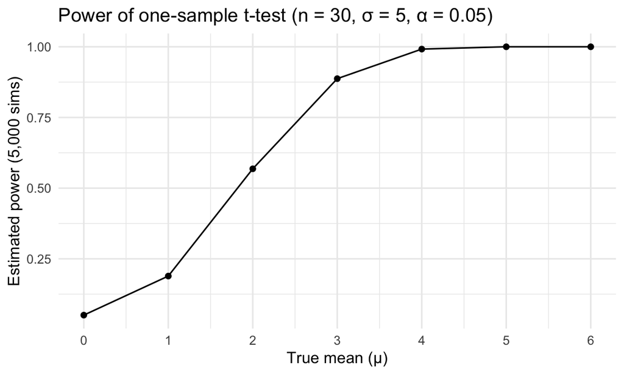

```r
power_df %>%
  ggplot(aes(mu, power)) +
  geom_point() + geom_line() +
  scale_x_continuous(breaks = mus, limits = c(0, 6)) +
  labs(title = "Power of one-sample t-test (n = 30, σ = 5, α = 0.05)",
       x = "True mean (μ)", y = "Estimated power (5,000 sims)") +
  theme_minimal()
```

Calculate the mu_hat

```r
mu_df=sim_res %>%
  group_by(mu) %>%
  summarize(
    mu_hat_all=mean(mu_hat),
    mu_hat_rej=mean(mu_hat[reject==TRUE])
  )
```

Create a plot to compare true mu and mu_hat

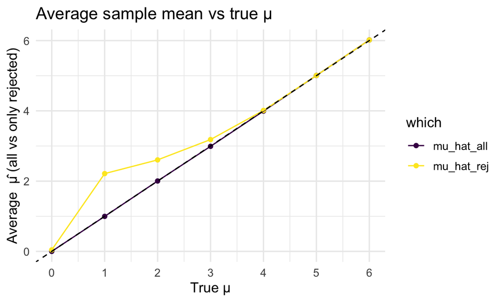

```r
mu_df |>
  pivot_longer(-mu, names_to = "which", values_to = "avg_mu_hat") |>
  ggplot(aes(mu, avg_mu_hat, color = which)) +
  geom_point() + geom_line() +
  geom_abline(slope = 1, intercept = 0, linetype = 2) +
  scale_x_continuous(breaks = 0:6, limits = c(0, 6)) +
  labs(title = "Average sample mean vs true μ",
       x = "True μ", y = "Average  μ̂ (all vs only rejected)") +
  theme_minimal(base_size = 12)
```

All samples (mu_hat_all): essentially unbiased.  
Significant-only (mu_hat_rej): inflated when power < 1, then converges to μ as power → 1.  
This is selection on statistical significance (the “winner’s curse”). When power isn’t 1, only datasets where random error pushes mu upward tend to pass p<0.05, so the conditional average among rejections is biased high. As the true effect grows (power → 1), nearly every sample rejects and the selection bias vanishes.

# Problem 3

```r
homi = read_csv("./homicide-data.csv") %>%
  janitor::clean_names()
```

Describe the raw data

```r
n_rows   = nrow(homi)
n_cols   = ncol(homi)
city_n   = homi %>%  distinct(city, state) %>%  nrow()
year_min = homi %>%  summarise(y = min(year(ymd(reported_date)), na.rm = TRUE)) %>%  pull(y)
year_max = homi %>%  summarise(y = max(year(ymd(reported_date)), na.rm = TRUE)) %>%  pull(y)
```

This raw dataset contains **one row per homicide case**, with 52179 observations and 12 variables, spanning 51 distinct city–state combinations from **2007** to **2017**. Core fields include the report date, victim demographics (age, sex, race), location (city, state, latitude/longitude), and the case disposition.

Create the new variable

```r
homi=homi %>%
  mutate(
    city_state = paste(city, state, sep = ", "),
    unsolved = disposition %in% c("Closed without arrest", "Open/No arrest")
  )

city_sum <- homi |>
  group_by(city_state) |>
  summarise(
    total    = n(),
    unsolved = sum(unsolved, na.rm = TRUE),
    .groups  = "drop"
  ) %>%
  arrange(desc(total))

Baltimore_homi =city_sum %>%
  filter(city_state == "Baltimore, MD")
head(Baltimore_homi)
```

```
## # A tibble: 1 × 3
##   city_state    total unsolved
##   <chr>         <int>    <int>
## 1 Baltimore, MD  2827     1825
```

Apply r`prop.test` function to Baltimore:

```r
pt_balt <- prop.test(
  x = Baltimore_homi$unsolved,
  n = Baltimore_homi$total
)

balt_est <- broom::tidy(pt_balt) |>
  select(estimate, conf.low, conf.high)

balt_est
```

```
## # A tibble: 1 × 3
##   estimate conf.low conf.high
##      <dbl>    <dbl>     <dbl>
## 1    0.646    0.628     0.663
```

Apply `prop.test` function to all:

```r
pb_city = city_sum %>%
  transmute(
    city_state,
    x = as.integer(unsolved),
    n = as.integer(total)
  ) %>%
  mutate(
    test = map2(x, n, ~ prop.test(.x, .y)),
    tidy = map(test, broom::tidy)
  ) %>%
  select(-test) %>%
  unnest(tidy) %>%
  select(city_state, x, n, estimate, conf.low, conf.high) %>%
  arrange(desc(estimate))
pb_city
```

```
## # A tibble: 51 × 6
##    city_state             x     n estimate conf.low conf.high
##    <chr>              <int> <int>    <dbl>    <dbl>     <dbl>
##  1 Chicago, IL         4073  5535    0.736    0.724     0.747
##  2 New Orleans, LA      930  1434    0.649    0.623     0.673
##  3 Baltimore, MD       1825  2827    0.646    0.628     0.663
##  4 San Bernardino, CA   170   275    0.618    0.558     0.675
##  5 Buffalo, NY          319   521    0.612    0.569     0.654
##  6 Miami, FL            450   744    0.605    0.569     0.640
##  7 Stockton, CA         266   444    0.599    0.552     0.645
##  8 Detroit, MI         1482  2519    0.588    0.569     0.608
##  9 Phoenix, AZ          504   914    0.551    0.518     0.584
## 10 Denver, CO           169   312    0.542    0.485     0.598
## # ℹ 41 more rows
```

Now we make a plot:

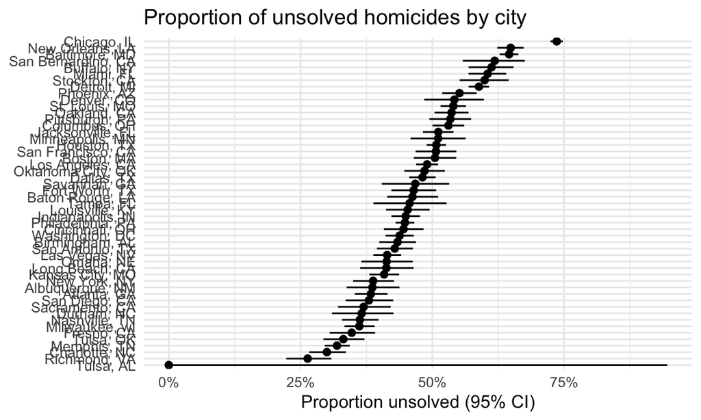

```r
pb_city %>%
  mutate(city_state = fct_reorder(city_state, estimate)) %>%
  ggplot(aes(city_state, estimate)) +
  geom_point(size = 1.8) +
  geom_errorbar(aes(ymin = conf.low, ymax = conf.high), width = 0) +
  coord_flip() +
  scale_y_continuous(labels = scales::percent_format(accuracy = 1)) +
  labs(
    title = "Proportion of unsolved homicides by city",
    x = NULL,
    y = "Proportion unsolved (95% CI)"
  ) +
  theme_minimal()
```